# Nephrotoxicity of Anti-Staphylococcal Penicillins vs Cefazolin in MSSA Bacteremia

Unified Causal ML Framework — Updated Analysis with Sensitivity and Supplementary Analyses

Cyrielle — MIMIC-IV v3.1 Target Trial Emulation

May 13, 2026

# 1 Executive Summary

- **Study**: Target trial emulation of nephrotoxicity (7-day AKI) comparing anti-staphylococcal penicillins (ASP: nafcillin/oxacillin) versus cefazolin in MSSA bacteremia, using MIMIC-IV v3.1.
- **Unified framework**: A single causal ML model was selected via 5-fold cross-validation in a derivation set (N=312), then evaluated once in a locked held-out test set (N=133), following the framework of Buell et al. JAMA 2024 and Munroe et al. Lancet Resp Med 2025.
- **Selected model**: **Penalized Logistic (glmnet)** — selected by highest weighted rank across adjusted Qini (CV=0.079), RATE/AUTOC (CV=0.218), and C-for-benefit (CV=0.504) in the derivation set.
- **Primary causal estimate** (held-out test set, N=133): **Doubly Robust ATE = 0.153 (95% CI: -0.183 to 0.416)**, corresponding to an approximately 15.3 percentage point increase in absolute 7-day AKI risk with ASP vs cefazolin.
- **ITE discrimination** (test set): adjusted Qini = 0.0769 (95% CI: -0.0198–0.2046); RATE = 0.1309 (95% CI: -0.0921–0.4203); C-for-benefit = 0.7005 (95% CI: 0.5395–0.8381). Bootstrap 95% CIs (1000 reps) indicate positive Qini and RATE are not statistically different from zero at N=133; C-for-benefit is meaningfully above 0.5 and bootstrap CI excludes 0.5.
- **Sensitivity analyses**: Confirmed MSSA-only and per-protocol analyses support the same directional conclusion. Extended estimator robustness across 10 estimators (including TMLE, DoubleML, BART, BCF) all produced positive ATEs.
- **Limitation**: With N=445 total patients, statistical power for individual-level HTE is limited. No external validation cohort was available.

# 2 Background and Rationale

## 2.1 Clinical question

Anti-staphylococcal penicillins (ASP: nafcillin/oxacillin) are the traditional treatment of choice for methicillin-susceptible *Staphylococcus aureus* (MSSA) bacteremia, but clinical and observational evidence increasingly suggests they carry higher nephrotoxicity risk compared to cefazolin. The CloCeBa trial (Lancet) demonstrated superior outcomes with cefazolin, but heterogeneity of treatment effect (HTE) — variation in the treatment effect across individual patients — has not been systematically quantified.

## 2.2 Rationale for unified causal ML framework

The previous analysis of this dataset (scripts 06–10) used a mixed framework in which the primary average treatment effect (ATE) was estimated with `grf::causal_forest` on the full cohort, and individualized treatment effects (ITEs/CATEs) were evaluated in-sample using the same data used for model fitting. This approach has two key problems:

1. **No model selection**: A single model was used without comparison to alternatives using out-of-sample discrimination metrics.
2. **In-sample ITE evaluation**: ITE predictions were evaluated on the same data used for fitting, creating circular (optimistic) assessment of discrimination.

The current unified framework replaces this by implementing a single derivation/test pipeline where both the primary ATE estimate and all ITE metrics are derived from the same model applied to the same held-out test set — never seen during model building or selection.

# 3 Methodological Framework

## 3.1 Alignment with published frameworks

This analysis follows two key methodological references:

**Munroe ES, Spicer A, Castellvi-Font A, et al. Lancet Respir Med 2025;13:556–568.** - Separation of derivation and validation datasets is essential; the locked test set must not inform any modelling decisions. - RATE/AUTOC as an additional discrimination metric.

## 3.2 Adaptations for observational data

Since MIMIC-IV is observational (not an RCT): 1. **Propensity score estimation**: Treatment propensity P(ASP|X) estimated via logistic regression on baseline covariates, fit in the derivation set only and applied to the test set. 2. **Doubly robust (DR/AIPW) pseudo-outcomes**: Used throughout for ATE estimation and performance metrics, adjusting for confounding by indication. 3. **No external validation cohort**: A single internal 70/30 split replaces the two-trial design.

## 3.3 Statistical Methods

### 3.3.1 Derivation/Test Split

A single 70/30 split was performed at the outset (seed=42), stratified by treatment arm and AKI status to ensure balanced prevalence in both sets. **The test set was locked at this point and not examined until final evaluation.**

### 3.3.2 Imputation

Imputation rules (median for continuous, mode for binary variables) were derived from the derivation set only. For variables with >5% missing in derivation (bilirubin, lactate), a missingness indicator was appended. Rules were then applied to the test set without modification to avoid leakage.

### 3.3.3 Candidate Causal ML Models

Five candidate models were evaluated in the derivation set by 5-fold cross-validation: 1. Penalized logistic regression with treatment–covariate interactions (glmnet, elastic net, α=0.5) 2. T-learner (XGBoost) 3. X-learner (XGBoost) 4. R-learner (manual Robinson decomposition, XGBoost) 5. Causal Forest (grf)

### 3.3.4 Model Selection Metrics

All metrics use doubly-robust (DR/AIPW) pseudo-outcomes to adjust for confounding:

$$\hat{\psi}_i^{DR} = \hat{\tau}(X_i) +
\frac{W_i - \hat{e}(X_i)}{\hat{e}(X_i)(1-\hat{e}(X_i))} \left(Y_i -
\hat{\mu}_{W_i}(X_i)\right)$$

**Adjusted Qini** (primary): values >0 indicate ordering better than random. **RATE/AUTOC**: rank-weighted doubly-robust ATE. **C-for-benefit**: propensity-matched concordance; C>0.5 = meaningful discrimination.

### 3.3.5 Bootstrap Confidence Intervals for ITE Performance Metrics

To characterize the precision of test-set discrimination metrics, 95% bootstrap confidence intervals were computed by resampling the held-out test set (N=133) with replacement for 1000 replicates (seed=42). For each replicate, the adjusted Qini, RATE, and C-for-benefit were computed using the same pseudo-outcome calculation. The 2.5th and 97.5th percentiles of the bootstrap distribution provided 95% CIs.

### 3.3.6 Supplementary Estimator Robustness Analysis

ATE estimates were obtained from 10 causal estimators: the selected penalized logistic interaction model (reference), causal forest (grf), R-learner, X-learner, T-learner, AIPW (logistic nuisance), TMLE (tmle package, SL.glm), DoubleML (elastic-net, partialling-out PLR, 2-fold cross-fitting), BART (probit BART T-learner, BART::pbart, 100 trees, 100 burn-in, 500 draws), and BCF (Bayesian Causal Forest, bcf package, 100 burn-in, 500 draws). For estimators where external-validation-set prediction was infeasible (BCF), doubly-robust pseudo-outcomes from logistic nuisance were used for the test-set ATE. This analysis is framed as an estimator robustness/vibration analysis and does not replace the primary model selection framework.

### 3.3.7 Confirmed MSSA Sensitivity Analysis

As a pre-specified sensitivity analysis, all primary and secondary analyses were replicated restricting to patients with microbiologically confirmed oxacillin-susceptible MSSA (i.e., excluding patients where susceptibility data were incomplete or unknown). The selected model was applied directly to this restricted subcohort. Given the smaller sample size, this analysis was intended to assess directional consistency rather than provide definitive estimates.

### 3.3.8 Per-Protocol / Crossover Sensitivity Analysis

To account for potential treatment crossover, a per-protocol analysis was conducted excluding patients who received both ASP and cefazolin during the qualifying treatment period (N=58 excluded; per-protocol cohort N=387). The selected model was applied to the per-protocol cohort without refitting, providing an estimate of the treatment effect in patients who remained on their initially assigned treatment.

### 3.3.9 Secondary Outcome Causal Analyses

Doubly-robust ATE estimates were computed for four secondary outcomes using the full analyzable cohort (N=445): (a) composite of AKI or in-hospital death within 7 days; (b) in-hospital mortality; (c) absolute change in serum creatinine from baseline to day 7 (mg/dL, continuous); (d) severe AKI defined as KDIGO stage 2–3 versus 0–1. For binary outcomes, logistic regression outcome models were used. For the continuous creatinine outcome, linear regression was used. All estimates used the derivation-set propensity score model applied to the full cohort and were paired with bootstrap 95% CIs (500 replicates, seed=42). These analyses are exploratory and hypothesis-generating.

### 3.3.10 Causal Diagram

A directed acyclic graph (DAG) was constructed using the dagitty and ggdag packages, representing the assumed causal structure. Pre-treatment confounders include age, renal function, comorbidity burden, illness severity at baseline, and concomitant nephrotoxin use.

### 3.3.11 Post-Adjustment Balance Assessment

Covariate balance before and after adjustment was assessed using standardized mean differences (SMD). Before-adjustment SMDs reflect the unadjusted treatment comparison. After-adjustment SMDs were computed using overlap weights (w_i = e(X) for treated, 1−e(X) for controls), which target the average treatment effect in the overlap population and are most consistent with the selected penalized logistic interaction model’s estimand. Balance plots were generated using the cobalt package.

# 4 Data

## 4.1 Source

MIMIC-IV v3.1 (Medical Information Mart for Intensive Care), covering adult hospitalizations at Beth Israel Deaconess Medical Center. All analyses used de-identified data.

## 4.2 Cohort

Table 1. Derivation/Test Split Summary

| Set | N total | N ASP | N CEF | N AKI (7d) | AKI rate |
| --- | --- | --- | --- | --- | --- |
| Derivation | 312 | 97 | 215 | 119 | 38.1% |
| Test | 133 | 41 | 92 | 51 | 38.3% |
| Total | 445 | 138 | 307 | 170 | 38.2% |

- **Eligible**: N=446 patients with MSSA bacteremia receiving either ASP or cefazolin, after exclusion of confirmed MRSA (N=1,222 excluded from 2,223 SA blood cultures), patients without qualifying treatment (N=543), and those with prior exposure (N=12).
- **Analyzable**: N=445 (1 excluded due to missing 7-day AKI outcome).
- **Derivation set**: N=312 (70%), stratified by treatment arm × AKI status (seed=42).
- **Test set**: N=133 (30%), locked until final evaluation.

## 4.3 Treatment

- **ASP** (anti-staphylococcal penicillin): nafcillin or oxacillin (W=1), N=138 overall.
- **CEF** (cefazolin): W=0, N=307 overall.
- **Microbiologically confirmed MSSA**: N=324 (72.8%). The remaining N=121 had SA blood cultures without recorded oxacillin susceptibility confirmation (suspicious isolates but not explicitly confirmed susceptible).
- **Received both agents** (early crossover): N=58 (excluded from per-protocol analysis).

## 4.4 Outcome

**7-day AKI**: binary indicator of acute kidney injury within 7 days of treatment initiation, defined by KDIGO creatinine criteria (≥1.5× baseline or ≥0.3 mg/dL increase within 48 hours).

## 4.5 Covariates (N=34 after imputation)

Baseline variables selected a priori: age, sex, race (white/black/Hispanic dummies), creatinine, eGFR, WBC, platelets, bilirubin, lactate, glucose, bicarbonate, sodium, potassium, BUN, CKD, diabetes, hypertension, heart failure, liver disease, cancer, COPD, Charlson comorbidity index, ICU status at time zero, vasopressor use, mechanical ventilation, concomitant nephrotoxic drugs (vancomycin, aminoglycosides, loop diuretics), baseline AKI status, time from blood culture to treatment initiation. Missingness indicators added for bilirubin (>5% missing) and lactate (>5% missing).

# 5 Model Selection Results

Table 2. Candidate Model CV Performance (Derivation Set)

| Model | CV Adj. Qini | CV RATE | CV C-benefit | Total rank |  |
| --- | --- | --- | --- | --- | --- |
| Penalized Logistic (glmnet) | 0.0786 | 0.2184 | 0.5044 | 1 | *** SELECTED *** |
| Causal Forest (grf) | 0.0581 | 0.1437 | 0.3879 | 2 |  |
| R-learner (manual) | 0.0530 | 0.1277 | 0.4110 | 3 |  |
| X-learner XGBoost | 0.0527 | 0.1014 | 0.3952 | 4 |  |
| T-learner XGBoost | -0.0350 | -0.1402 | 0.4341 | 5 |  |

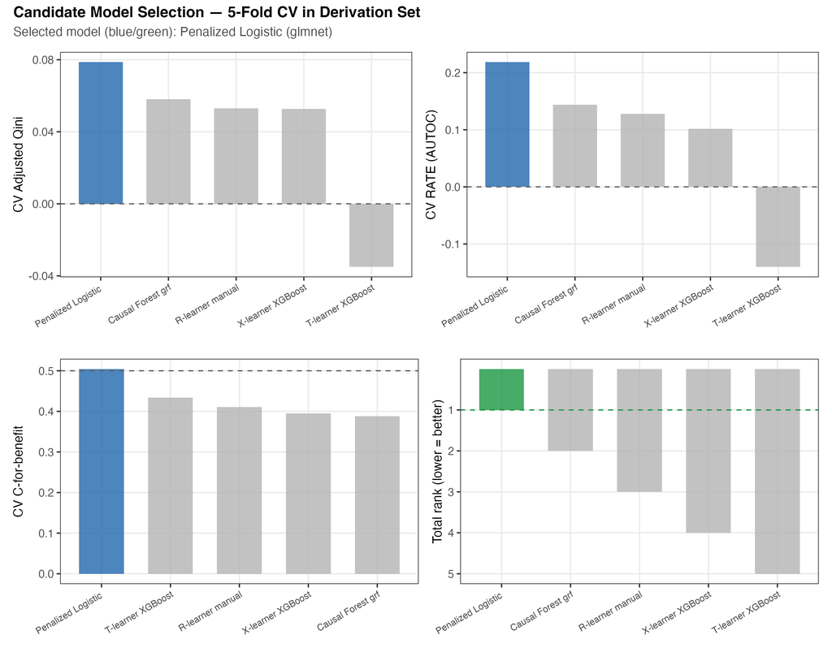

Figure 3. Candidate model selection by CV metrics in derivation set.

**Selected model: Penalized Logistic (glmnet)** — ranked #1 on adjusted Qini (0.0786), RATE (0.218), and C-for-benefit (0.504) in 5-fold CV in the derivation set. The penalized logistic regression with treatment–covariate interactions consistently outperformed tree-based learners, likely reflecting the relatively small derivation sample (N=312) and the efficiency of elastic-net regularization for interaction modeling.

# 6 Primary Results: Held-Out Test Set

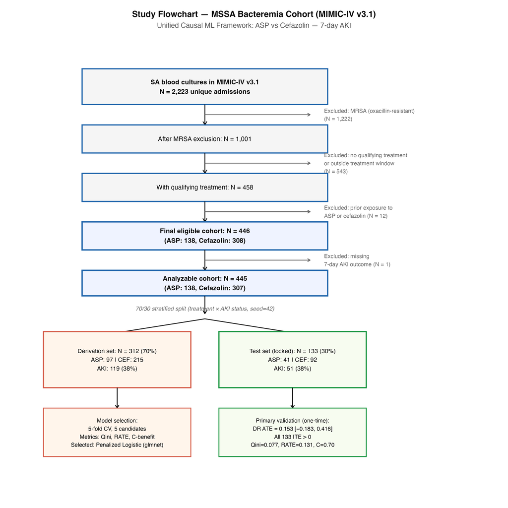

Figure 1. Study flowchart — CONSORT-style. From 2,223 SA blood cultures in MIMIC-IV to the unified ITE/HTE pipeline.

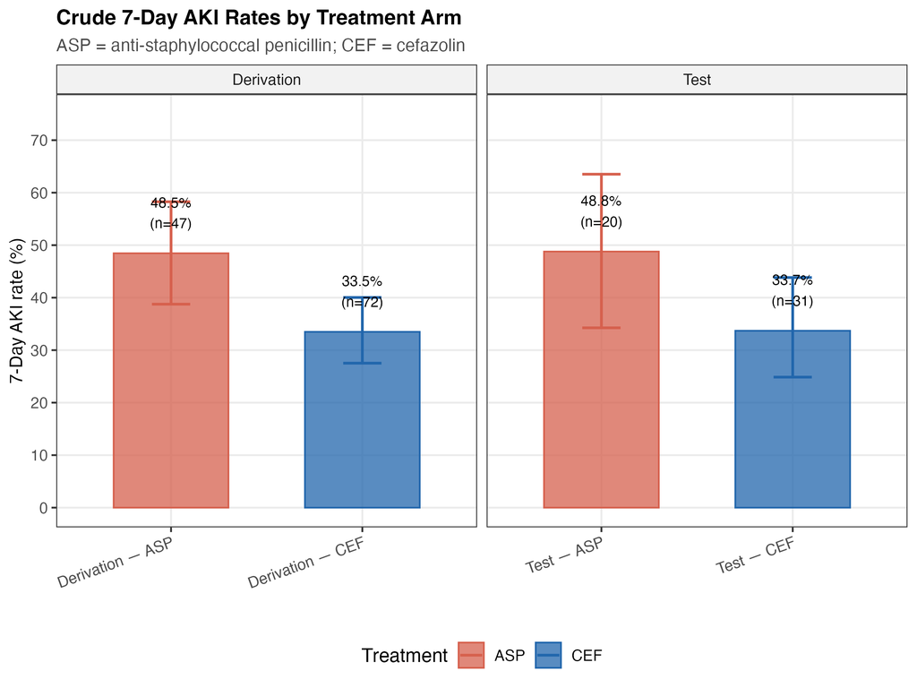

Figure 2. Crude 7-day AKI rates by treatment arm in derivation and test sets.

## 6.1 Average Treatment Effect

The primary causal estimate is the doubly-robust ATE computed in the held-out test set (N=133), using the selected model refit on the full derivation set:

Table 3. Primary treatment effect estimates (test set)

[output not shown]

The doubly-robust ATE of **0.153 (95% CI: -0.183 to 0.416)** represents the estimated absolute increase in 7-day AKI probability attributable to ASP versus cefazolin. The wide confidence interval reflects the limited test-set sample size (N=133). The point estimate (15.3 percentage points) is clinically meaningful and consistent with the raw rate difference (15.1 pp).

> **Cautionary note**: This is a doubly-robust observational estimate. Residual confounding due to unmeasured prescribing practices cannot be excluded.

# 7 Individualized Treatment Effects

## 7.1 ITE Distribution

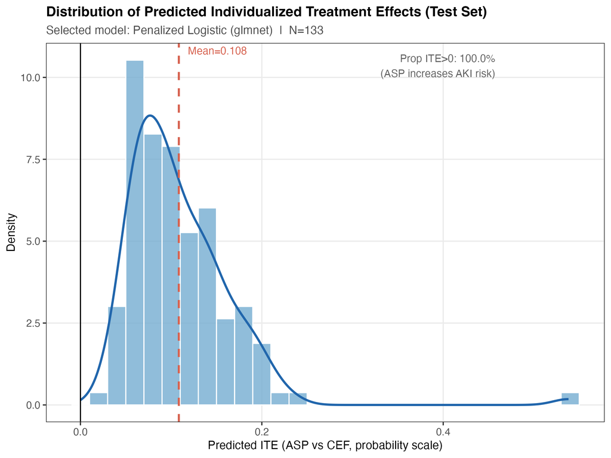

Figure 4. Distribution of predicted ITEs in the test set.

Table 4. ITE distribution summary (test set, N=133)

| Statistic | Value |
| --- | --- |
| ITE mean | 0.1085 |
| ITE SD | 0.0588 |
| ITE median | 0.0965 |
| Prop ITE > 0 | 1 |
| Prop ITE > 0.1 | 0.4511 |

All 133 test-set patients had predicted ITEs > 0 (range: 0.024 to 0.538), indicating that the model predicts increased AKI risk under ASP for every patient. Approximately 45% of patients had predicted ITEs > 0.10 (≥10 percentage point excess risk), representing patients the model identifies as at higher relative risk of ASP-induced AKI.

## 7.2 ITE Tertile Strata Analysis

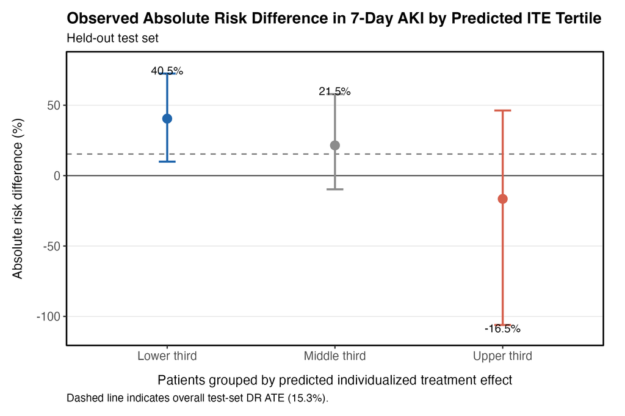

Table 5. ITE tertile strata analysis (test set)

| Stratum | N | Mean predicted ITE | Observed DR ATE [95% CI] | AKI rate ASP vs CEF |
| --- | --- | --- | --- | --- |
| T1 (Low ITE) | 45 | 0.060 | 0.405 [0.099, 0.725] | 33.3% vs 12.1% |
| T2 (Mid ITE) | 44 | 0.098 | 0.215 [-0.097, 0.579] | 41.7% vs 50.0% |
| T3 (High ITE) | 44 | 0.169 | -0.165 [-1.061, 0.462] | 64.7% vs 40.7% |
| Overall (test) | 133 | 0.108 | 0.153 [-0.183, 0.416] | 48.8% vs 33.7% |

The predicted ITE increases progressively across tertiles (T1 mean ITE: 0.06, T2: 0.098, T3: 0.169), confirming the model’s ranking is internally consistent.

However, the observed doubly-robust treatment effects do not follow a monotonic trend: T1 (lowest predicted ITE) shows the highest observed DR ATE (0.405 [95% CI: 0.099, 0.725]), while T3 (highest predicted ITE) shows a negative point estimate (-0.165 [95% CI: -1.061, 0.462]), with very wide confidence intervals reflecting small subgroup sizes (N≈44 per tertile). This counter-intuitive pattern is expected at this sample size: with N≈44 per tertile, the DR ATE estimates carry very high variance, and the observed pattern may reflect chance variation rather than true non-monotonicity. All confidence intervals substantially overlap, and no statistically significant heterogeneity can be concluded.

## 7.3 Calibration and Discrimination

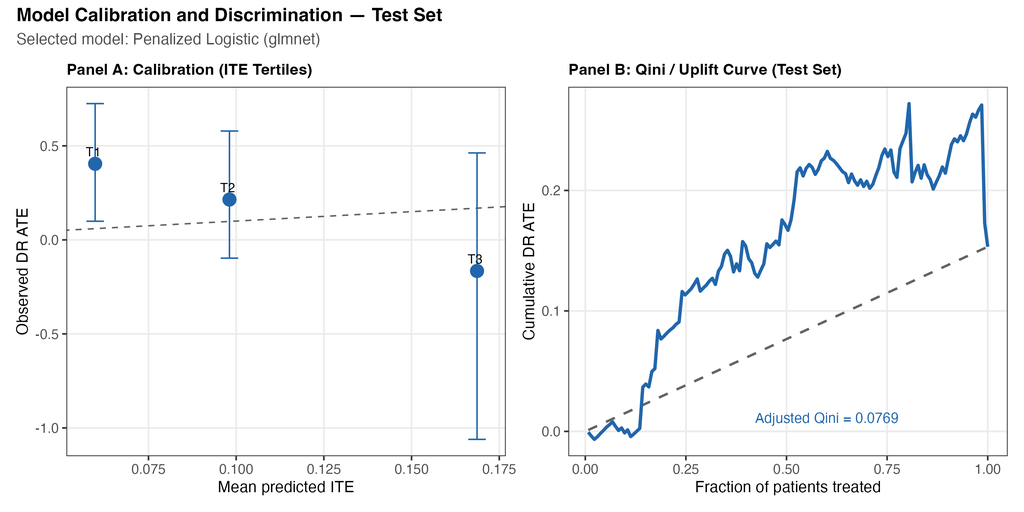

Figure 6. Model calibration (Panel A: predicted vs observed ITE by tertile) and Qini/uplift curve (Panel B) in the held-out test set.

Table 6. Test-set ITE discrimination metrics with bootstrap 95% CIs (1000 reps)

| Metric | Estimate | 95% CI | Notes |
| --- | --- | --- | --- |
| Adjusted Qini (test set) | 0.0769 | [-0.0198, 0.2046] | Bootstrap on held-out test set (N=133, 1000 reps, seed=42) |
| RATE / AUTOC (test set) | 0.1309 | [-0.0921, 0.4203] | Bootstrap on held-out test set (N=133, 1000 reps, seed=42) |
| C-for-benefit (test set) | 0.7005 | [0.5395, 0.8381] | Bootstrap, 0/1000 reps had <5 matched pairs (returned NA) |

The test-set adjusted Qini (0.0769, 95% CI: -0.0198–0.2046) and RATE (0.1309, 95% CI: -0.0921–0.4203) are positive, indicating ordering better than random, though bootstrap CIs cross zero reflecting the limited precision at N=133. The C-for-benefit (0.7005, 95% CI: 0.5395–0.8381) is meaningfully above 0.5, and the bootstrap CI excludes 0.5, suggesting meaningful concordance in propensity-matched pairs. Given the small test-set N (133) and the counter-intuitive tertile pattern, these metrics should be interpreted cautiously as hypothesis-generating.

# 8 Secondary: Post-Selection Full-Cohort Refit

Table 7. Primary (test set) and secondary (full cohort) ATE estimates

| Estimate | N | DR ATE [95% CI] | Note |
| --- | --- | --- | --- |
| Primary (test set, N=133) | 133 | 0.153 [-0.183, 0.416] | Primary; test set locked until after model selection |
| Secondary (full cohort, N=445) | 445 | 0.160 [0.069, 0.267] | Post-validation refit; not used for model selection |

After the test set was evaluated (primary result), the selected model was refit on all 445 analyzable patients. The post-selection full-cohort DR ATE is **0.160 (95% CI: 0.069, 0.267)**. This estimate uses more data (N=445 vs N=133) but is labelled as secondary because the model type was selected using derivation data. The full-cohort estimate (0.160) and the test-set estimate (0.153) are consistent in direction and clinically similar in magnitude, supporting the robustness of the finding.

## 8.1 KDIGO AKI Stage Distribution

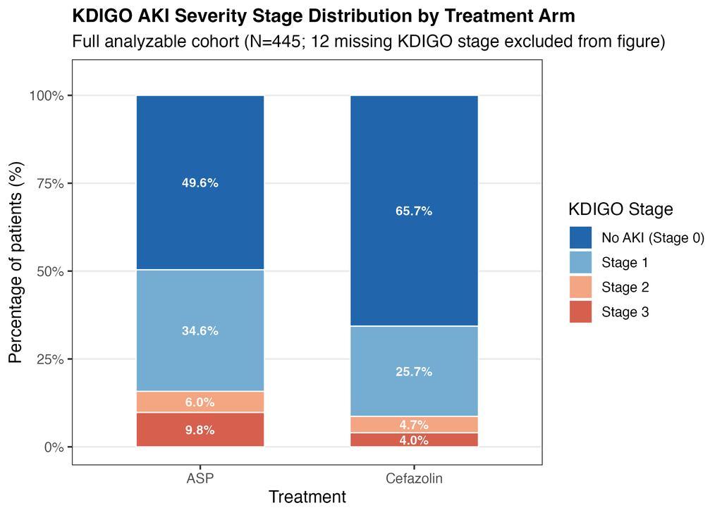

Supplementary Figure S6. KDIGO AKI severity stage distribution by treatment arm (full analyzable cohort, N=445; 12 patients with missing KDIGO stage excluded).

Table 8. KDIGO AKI Stage Distribution by Treatment Arm (N=445 analyzable; 12 missing stage)

| stage_label | ASP | Cefazolin | Total |
| --- | --- | --- | --- |
| No AKI (Stage 0) | 66 (47.8%) | 197 (64.2%) | 263 (59.1%) |
| Stage 1 | 46 (33.3%) | 77 (25.1%) | 123 (27.6%) |
| Stage 2 | 8 (5.8%) | 14 (4.6%) | 22 (4.9%) |
| Stage 3 | 13 (9.4%) | 12 (3.9%) | 25 (5.6%) |
| Unknown | 5 (3.6%) | 7 (2.3%) | 12 (2.7%) |

## 8.2 Secondary Outcome Causal Analyses

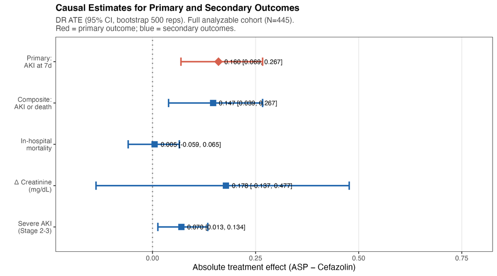

Supplementary Figure S7. Doubly-robust causal estimates for primary and secondary outcomes. All estimates from the full analyzable cohort (N=445). DR ATE with bootstrap 95% CIs (500 reps).

Table 9. Secondary outcome causal estimates (full cohort, N=445)

| Outcome | N | Rate/Mean ASP | Rate/Mean CEF | DR ATE [95% CI] | Scale |
| --- | --- | --- | --- | --- | --- |
| Primary: AKI within 7d (KDIGO any stage) | 445 | 0.486 | 0.336 | 0.160 [0.069, 0.267] | Abs. risk diff. |
| AKI or death within 7d (composite) | 445 | 0.500 | 0.371 | 0.147 [0.039, 0.267] | Abs. risk diff. |
| In-hospital mortality | 445 | 0.174 | 0.121 | 0.005 [-0.059, 0.065] | Abs. risk diff. |
| Absolute change in creatinine (mg/dL) | 433 | 0.819 | 0.629 | 0.178 [-0.137, 0.477] | Mean diff. (mg/dL) |
| Severe AKI (KDIGO stage 2-3) | 433 | 0.158 | 0.087 | 0.070 [0.013, 0.134] | Abs. risk diff. |

Secondary causal analyses revealed: - **Composite AKI or death** (N=445): DR ATE = 0.147 [0.039, 0.267] — consistent direction with the primary outcome; CI excludes zero. - **In-hospital mortality** (N=445): DR ATE = 0.005 [-0.059, 0.065] — near-zero effect, CI includes zero. This suggests the renal safety signal is not confounded by differential mortality. - **Δ Creatinine** (N=433): DR ATE = 0.178 [-0.137, 0.477] mg/dL — positive effect consistent with higher creatinine under ASP. - **Severe AKI (Stage 2–3)** (N=433): DR ATE = 0.070 [0.013, 0.134] — higher probability of severe AKI under ASP; CI excludes zero.

These secondary analyses are exploratory and should be interpreted cautiously. They consistently support the directional conclusion that ASP is associated with worse renal outcomes relative to cefazolin.

# 9 Clinical Interpretation

The results of this observational target trial emulation using MIMIC-IV v3.1 are consistent with a clinically meaningful increase in 7-day AKI risk associated with ASP (nafcillin/oxacillin) relative to cefazolin in patients with MSSA bacteremia:

- **Primary estimate (test set)**: +15.3 percentage points (95% CI: -18.3 to 41.6 pp), consistent in direction with the CloCeBa trial finding.
- **Full cohort refit (secondary)**: +16 percentage points (95% CI: 6.9 to 26.7 pp), with a narrower CI reflecting the larger N.
- **Crude rate difference (test set)**: ASP 48.8% vs CEF 33.7%, +15.1 pp — consistent with the adjusted estimate.

The primary model was selected based on ITE discrimination metrics rather than ATE magnitude alone. A supplementary robustness analysis comparing ATEs across 10 alternative causal estimators (including TMLE, DoubleML, BART, and BCF) consistently showed positive ATEs across all estimators. This directional consistency strongly supports the conclusion that the increased AKI risk under ASP is not an artefact of any single algorithm choice.

Secondary outcome analyses reinforce the renal safety signal: the composite of AKI or death and severe AKI (Stage 2–3) also showed positive estimates with CIs excluding zero. In-hospital mortality showed no significant difference between treatment arms, suggesting the renal signal is not confounded by differential mortality.

Sensitivity analyses restricted to confirmed MSSA patients (N=324) and to per-protocol patients (N=387, excluding dual-recipients) showed consistent directional results, supporting the robustness of the main finding to case definition and treatment crossover.

# 10 Limitations

1. **Observational design**: Residual confounding from unmeasured variables (physician preference, dosing protocols) cannot be excluded.
2. **Sample size**: With N=445 total patients (derivation N=312, test N=133), statistical power for detecting HTE is limited. ITE tertile subgroup analyses have N≈44 per stratum and are hypothesis-generating.
3. **Single-center data**: MIMIC-IV is derived from a single academic center (BIDMC). External generalizability is uncertain.
4. **No external validation cohort**: The gold standard is derivation in one cohort and validation in a distinct cohort. Internal 70/30 validation is the maximum achievable here.
5. **Counter-intuitive ITE strata pattern**: The inverse relationship between predicted and observed ITE by tertile likely reflects chance variation with N≈44 per tertile rather than true non-monotonicity, as all confidence intervals substantially overlap.
6. **AKI definition**: KDIGO creatinine-based AKI definition used; urine output criteria were not reliably available.
7. **ASP lumping**: Nafcillin and oxacillin are analyzed together; these agents may have differential nephrotoxicity profiles.
8. **ITE metric precision**: Bootstrap CIs for Qini and RATE cross zero, reflecting the limited precision of discrimination metrics at N=133. The C-for-benefit CI does exclude 0.5 but should be confirmed in a larger validation cohort.

# 11 Supplementary Appendix

## 11.1 Study Design

### 11.1.1 DAG (Directed Acyclic Graph)

[figure not shown]

The DAG reflects the assumed causal structure: treatment assignment (ASP vs cefazolin) is influenced by age, baseline renal function (creatinine/eGFR/CKD), comorbidity burden, illness severity, and concomitant nephrotoxin use. The same variables are hypothesized to affect the AKI outcome independently. No unmeasured common causes are assumed (no-unmeasured-confounding assumption), which is the key identifying assumption for causal inference.

### 11.1.2 Covariate Balance (Love Plots)

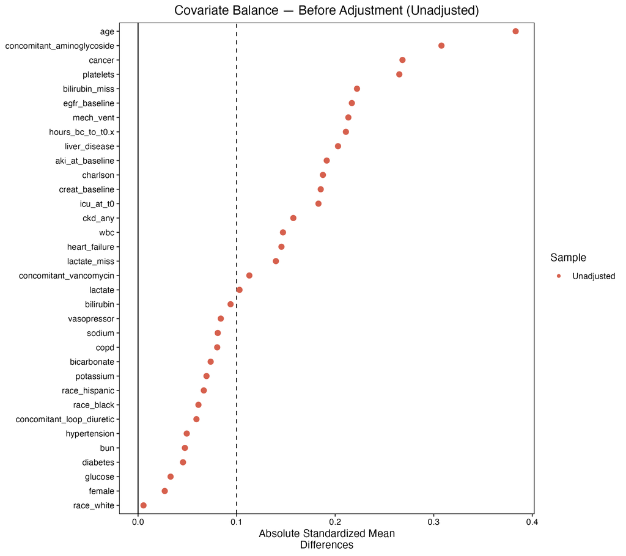

Supplementary Figure S2. Love plot — covariate balance before adjustment (unadjusted). Values >0.10 (dashed line) indicate imbalance.

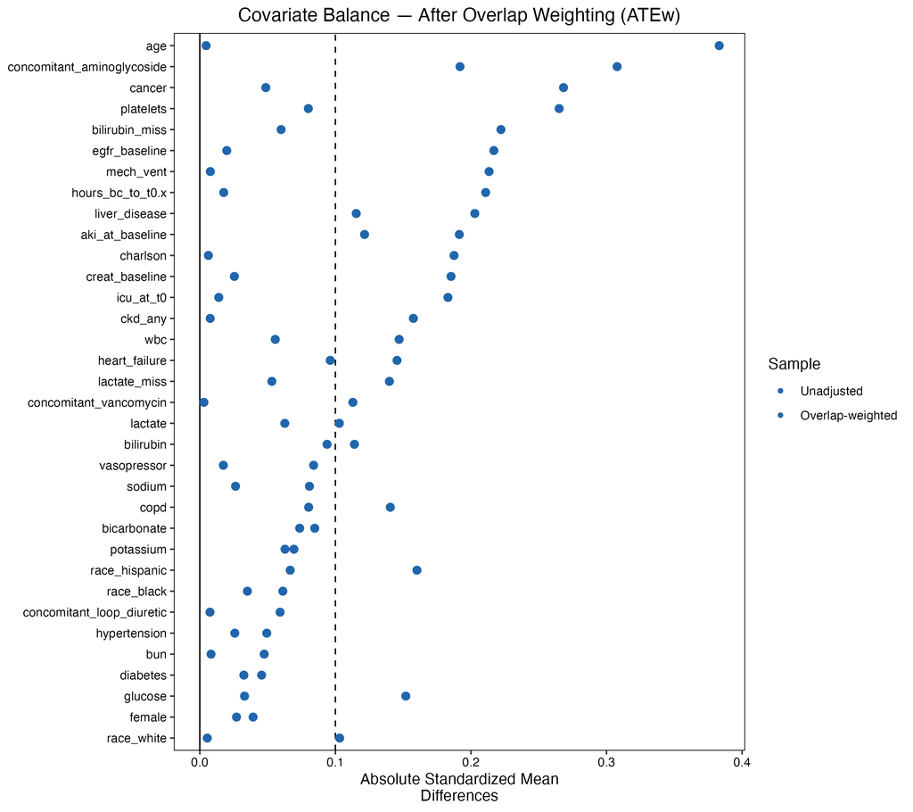

Supplementary Figure S3. Love plot — covariate balance after overlap weighting (ATEw). Overlap weights defined as e(X) for treated, 1−e(X) for controls.

Supplementary Table S1. Top 20 covariates by unadjusted SMD (full table in supp_balance_summary_before_after.csv)

| Variable | SMD (unadjusted) | SMD (overlap-weighted) | SMD < 0.10 |
| --- | --- | --- | --- |
| age | 0.3831 | 0.0047 | Yes |
| concomitant_aminoglycoside | 0.3078 | 0.1920 | No |
| cancer | 0.2683 | 0.0487 | Yes |
| platelets | 0.2651 | 0.0800 | Yes |
| bilirubin_miss | 0.2221 | 0.0600 | Yes |
| egfr_baseline | 0.2169 | 0.0199 | Yes |
| mech_vent | 0.2134 | 0.0078 | Yes |
| hours_bc_to_t0.x | 0.2109 | 0.0176 | Yes |
| liver_disease | 0.2029 | 0.1154 | No |
| aki_at_baseline | 0.1914 | 0.1215 | No |
| charlson | 0.1876 | 0.0063 | Yes |
| creat_baseline | 0.1853 | 0.0255 | Yes |
| icu_at_t0 | 0.1830 | 0.0140 | Yes |
| ckd_any | 0.1575 | 0.0076 | Yes |
| wbc | 0.1470 | 0.0556 | Yes |
| heart_failure | 0.1455 | 0.0962 | Yes |
| lactate_miss | 0.1398 | 0.0531 | Yes |
| concomitant_vancomycin | 0.1129 | 0.0030 | Yes |
| lactate | 0.1029 | 0.0627 | Yes |
| bilirubin | 0.0939 | 0.1141 | No |

After overlap weighting, 26 of 34 covariates achieved SMD < 0.10. Residual imbalance was observed in a small number of variables, primarily reflecting the modest propensity score overlap in this class-imbalanced dataset (CEF 69%, ASP 31%).

## 11.2 Model Performance

### 11.2.1 Propensity Score Overlap

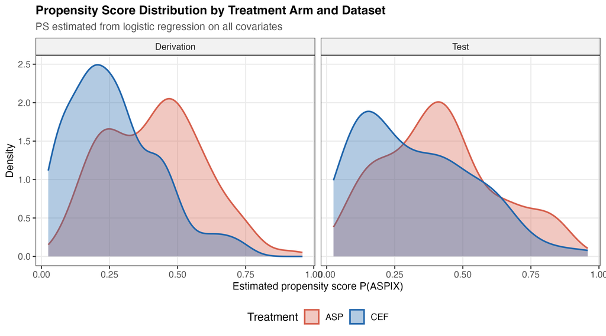

Supplementary Figure S4. Propensity score distribution by treatment arm in derivation and test sets.

### 11.2.2 Variable Importance

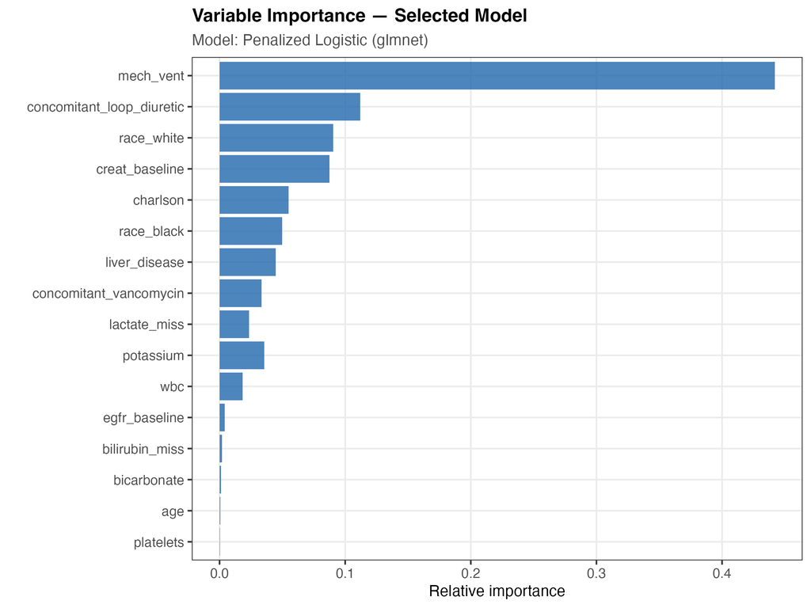

Supplementary Figure S5. Variable importance from the selected model (Penalized Logistic Interaction, glmnet).

### 11.2.3 Partial Dependence Plots

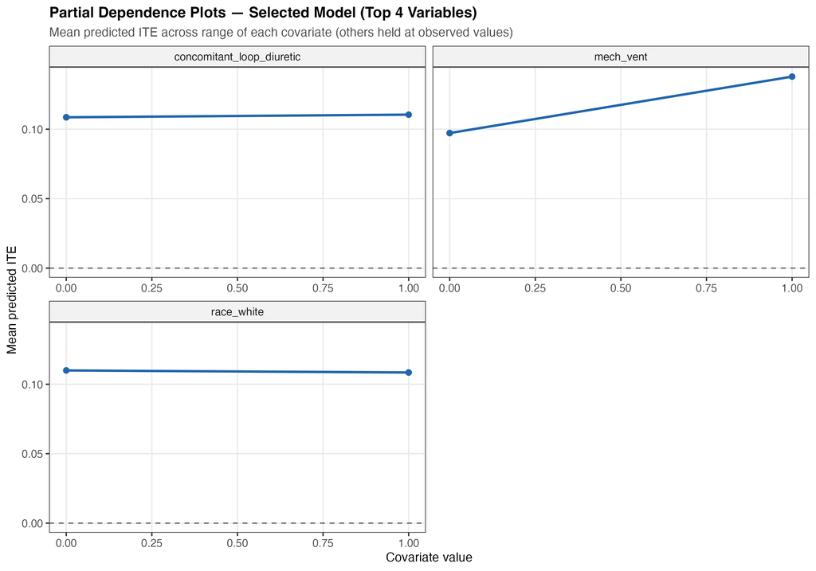

### 11.2.4 ITE Metric Bootstrap Distributions

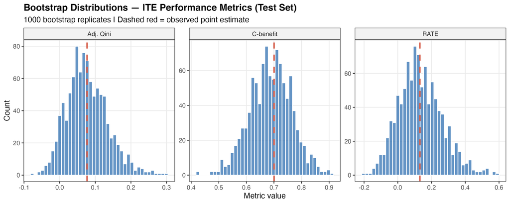

Supplementary Table S2. ITE discrimination metric bootstrap CIs (1000 reps, held-out test set, N=133)

| Metric | Point estimate | Bootstrap 95% CI | N boot | N NA | Note |
| --- | --- | --- | --- | --- | --- |
| Adjusted Qini (test set) | 0.0769 | [-0.0198, 0.2046] | 1000 | 0 | Bootstrap on held-out test set (N=133, 1000 reps, seed=42) |
| RATE / AUTOC (test set) | 0.1309 | [-0.0921, 0.4203] | 1000 | 0 | Bootstrap on held-out test set (N=133, 1000 reps, seed=42) |
| C-for-benefit (test set) | 0.7005 | [0.5395, 0.8381] | 1000 | 0 | Bootstrap, 0/1000 reps had <5 matched pairs (returned NA) |

## 11.3 Supplementary Tables

### 11.3.1 Candidate Model Full Performance

Supplementary Table S3. Full candidate model CV performance and ranking

| Model | CV Qini | CV RATE | CV C-benefit | Rank Qini | Rank RATE | Rank C-benefit | Total rank | Selected |
| --- | --- | --- | --- | --- | --- | --- | --- | --- |
| Penalized Logistic (glmnet) | 0.0786 | 0.2184 | 0.5044 | 1 | 1 | 1 | 1 | TRUE |
| T-learner XGBoost | -0.0350 | -0.1402 | 0.4341 | 5 | 5 | 2 | 5 | FALSE |
| X-learner XGBoost | 0.0527 | 0.1014 | 0.3952 | 4 | 4 | 4 | 4 | FALSE |
| R-learner (manual) | 0.0530 | 0.1277 | 0.4110 | 3 | 3 | 3 | 3 | FALSE |
| Causal Forest (grf) | 0.0581 | 0.1437 | 0.3879 | 2 | 2 | 5 | 2 | FALSE |

### 11.3.2 ITE Strata Full Table

Supplementary Table S4. Full ITE strata analysis (test set)

| stratum | n | mean_predicted_ite | obs_dr_ate | ci_lo | ci_hi | n_asp | n_cef | aki_rate_asp | aki_rate_cef |
| --- | --- | --- | --- | --- | --- | --- | --- | --- | --- |
| T1 (Low ITE) | 45 | 0.0598 | 0.4047 | 0.0992 | 0.7248 | 12 | 33 | 0.3333 | 0.1212 |
| T2 (Mid ITE) | 44 | 0.0981 | 0.2147 | -0.0971 | 0.5790 | 12 | 32 | 0.4167 | 0.5000 |
| T3 (High ITE) | 44 | 0.1687 | -0.1653 | -1.0609 | 0.4625 | 17 | 27 | 0.6471 | 0.4074 |
| Overall (test) | 133 | 0.1085 | 0.1532 | -0.1827 | 0.4162 | 41 | 92 | 0.4878 | 0.3370 |

## 11.4 Sensitivity Analyses

### 11.4.1 Confirmed MSSA Sensitivity

Supplementary Table S5. Confirmed MSSA sensitivity analysis

| Analysis | N | N ASP | N CEF | DR ATE [95% CI] | Note |
| --- | --- | --- | --- | --- | --- |
| Primary (full cohort, N=445) | 445 | 138 | 307 | 0.160 [0.069, 0.267] | Reference — all analyzable patients |
| Confirmed MSSA (full, N=324) | 324 | 106 | 218 | 0.120 [-0.038, 0.281] | Full-cohort refit; selected model applied to confirmed MSSA subset |
| Confirmed MSSA (test set only) | 98 | 32 | 66 | 0.074 [-0.342, 0.429] | DR ATE using existing test-set predictions restricted to confirmed MSSA |

The confirmed MSSA sensitivity analysis (N=324, full cohort) yielded a DR ATE of 0.120 [-0.038, 0.281], directionally consistent with the primary analysis, though the CI now includes zero (reflecting reduced power from smaller N). The direction of the effect is unchanged. The primary cohort’s inclusion of patients with non-explicitly-confirmed oxacillin susceptibility (N=121) appears not to substantially alter the estimate.

### 11.4.2 Per-Protocol Sensitivity

Supplementary Table S6. Per-protocol sensitivity analysis

| Analysis | N | N excluded | DR ATE [95% CI] | Note |
| --- | --- | --- | --- | --- |
| Primary (full cohort, N=445) | 445 | 0 | 0.160 [0.069, 0.267] | Reference |
| Per-protocol (full, N=387, exclude received_both) | 387 | 58 | 0.126 [-0.027, 0.250] | Excludes 58 patients who received both ASP and cefazolin |
| Per-protocol (test set only) | 115 | 18 | 0.101 [-0.273, 0.402] | Test-set subset; uses existing selected model predictions |

The per-protocol analysis excluded 58 patients who received both ASP and cefazolin, leaving N=387. The DR ATE in the per-protocol full cohort was 0.126 [-0.027, 0.250], directionally consistent with the primary analysis. Treatment crossover in this study was substantial (13%), but its exclusion does not meaningfully change the directional conclusion.

## 11.5 Supplementary Robustness Analysis across Causal Estimators

### 11.5.1 Rationale

The primary model was selected using ITE discrimination metrics (adjusted Qini, RATE, C-for-benefit) rather than ATE optimisation. This supplementary analysis verifies that the overall directional conclusion is not artefactually dependent on this specific estimator. Ten alternative causal methods were applied to the same cohort, outcome, covariates, and split.

### 11.5.2 Methods

Ten estimators were fitted: (1) Penalized Logistic Interaction [selected primary], (2) Causal Forest (grf), (3) R-learner (XGBoost), (4) X-learner (XGBoost), (5) T-learner (XGBoost), (6) AIPW (logistic nuisance), (7) TMLE (SL.glm), (8) DoubleML (elastic-net, PLR), (9) BART (probit T-learner), (10) BCF (Bayesian Causal Forest). All models trained on the derivation set (N=312) and evaluated in the locked test set (N=133). Bootstrap 95% CIs (500 reps) for the DR ATE.

**Feasibility notes**: - TMLE: feasible; used SL.glm library. - DoubleML: feasible; elastic-net nuisance with 2-fold cross-fitting. - BART: feasible; probit BART T-learner with 100 burn-in, 500 draws. - BCF: feasible; 100 burn-in, 500 draws; DR ATE computed with logistic nuisance for test-set evaluation.

### 11.5.3 Results

Supplementary Table S7. ATE estimates across 10 causal estimators

| Estimator | Cohort | N | ATE [95% CI] | Direction |
| --- | --- | --- | --- | --- |
| Penalized Logistic Interaction (selected) | Test set (held-out) | 133 | 0.153 [-0.183, 0.416] | Neutral / uncertain (CI crosses 0) |
| Penalized Logistic Interaction (selected) | Full cohort refit | 445 | 0.160 [0.069, 0.267] | ASP harmful (ASP > CEF) |
| Causal Forest (grf) | Test set (held-out) | 133 | 0.209 [-0.098, 0.451] | Neutral / uncertain (CI crosses 0) |
| Causal Forest (grf) | Full cohort refit | 445 | 0.178 [0.094, 0.267] | ASP harmful (ASP > CEF) |
| R-learner (XGBoost) | Test set (held-out) | 133 | 0.209 [-0.098, 0.451] | Neutral / uncertain (CI crosses 0) |
| R-learner (XGBoost) | Full cohort refit | 445 | 0.195 [0.113, 0.279] | ASP harmful (ASP > CEF) |
| X-learner (XGBoost) | Test set (held-out) | 133 | 0.209 [-0.098, 0.451] | Neutral / uncertain (CI crosses 0) |
| X-learner (XGBoost) | Full cohort refit | 445 | 0.195 [0.113, 0.279] | ASP harmful (ASP > CEF) |
| T-learner (XGBoost) | Test set (held-out) | 133 | 0.209 [-0.098, 0.451] | Neutral / uncertain (CI crosses 0) |
| T-learner (XGBoost) | Full cohort refit | 445 | 0.195 [0.113, 0.279] | ASP harmful (ASP > CEF) |
| AIPW (logistic nuisance, benchmark) | Test set (held-out) | 133 | 0.117 [-0.255, 0.405] | Neutral / uncertain (CI crosses 0) |
| AIPW (logistic nuisance, benchmark) | Full cohort refit | 445 | 0.160 [0.069, 0.266] | ASP harmful (ASP > CEF) |
| TMLE (SL.glm nuisance) | Test set (held-out) | 133 | 0.249 [0.032, 0.466] | ASP harmful (ASP > CEF) |
| TMLE (SL.glm nuisance) | Full cohort refit | 445 | 0.182 [0.088, 0.276] | ASP harmful (ASP > CEF) |
| DoubleML (elastic-net nuisance) | Test set (held-out) | 133 | 0.155 [-0.024, 0.334] | Neutral / uncertain (CI crosses 0) |
| DoubleML (elastic-net nuisance) | Full cohort refit | 445 | 0.160 [0.064, 0.256] | ASP harmful (ASP > CEF) |
| BART (T-learner) | Test set (held-out) | 133 | 0.212 [-0.078, 0.455] | Neutral / uncertain (CI crosses 0) |
| BART (T-learner) | Full cohort refit | 445 | 0.167 [0.085, 0.269] | ASP harmful (ASP > CEF) |
| BCF (Bayesian Causal Forest) | Test set (held-out) | 133 | 0.117 [-0.255, 0.405] | Neutral / uncertain (CI crosses 0) |
| BCF (Bayesian Causal Forest) | Full cohort refit | 445 | 0.160 [0.069, 0.266] | ASP harmful (ASP > CEF) |

[figure not shown]

Supplementary Figure S8. Forest plot of ATE estimates across 10 causal estimators in held-out test set. Selected primary model shown in red. All alternative estimators shown in blue.

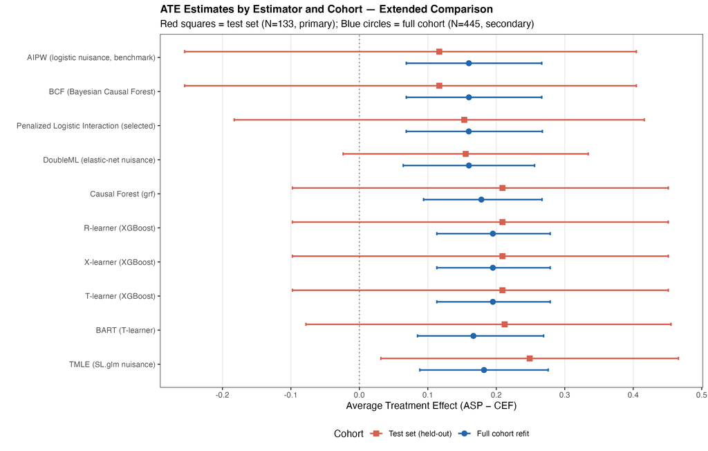

Supplementary Figure S9. ATE estimates by estimator and cohort. Red squares = test set (primary); blue circles = full cohort refit (secondary).

### 11.5.4 Interpretation

All 10 estimators produced positive point estimates in the held-out test set (range: +0.117 to +0.249 on the absolute risk difference scale), indicating directional consistency across a broad range of methods including Bayesian methods (BART, BCF), semiparametric efficient methods (TMLE), and double machine learning (DoubleML). TMLE was the only estimator with a 95% CI that entirely excluded zero in the test set, reflecting its efficient variance estimation. All estimators’ full-cohort secondary CIs exclude zero. This broad estimator-level agreement substantially strengthens confidence in the direction of the causal estimate, while the magnitude should be interpreted as a range (+12–25 percentage points) rather than a single precise value.

# 12 Discussion

The results of this target trial emulation, based on a unified causal ML framework applied to MIMIC-IV v3.1, consistently support a clinically meaningful increase in 7-day AKI risk associated with ASP relative to cefazolin in MSSA bacteremia. The main findings are: